# Protein structure and structural bioinformatics

Practical 7: Genomics, systems biology and multi-omics

## Learning objectives

Interpret coordinate units and residue identifiers; calculate pairwise distances and non-neighbour contacts; distinguish geometric contacts from functional evidence.

## Biological question and data

Which residue pairs lie close together in a supplied protein-coordinate model?

The six coordinates are invented C-alpha positions in angstroms, not a protein database structure. Euclidean proximity is calculated under a supplied cutoff; consecutive residues are excluded from the contact summary.

No biological download is required. Numerical inputs are hypothetical, not observed animal data. The runnable examples use base R. Count and abundance units are specified where used.

## 1. Inspect coordinates and distances

Rows represent residues. Distance is calculated in the stated coordinate system.

**Show R code**

```r
xyz <- rbind(c(0,0,0),c(3.8,0,0),c(7.6,0,0),c(7.6,3.8,0),c(3.8,3.8,0),c(0,3.8,0))
rownames(xyz) <- paste0("residue",1:6)
D <- as.matrix(dist(xyz))
round(D,2)
```

```
         residue1 residue2 residue3 residue4 residue5 residue6
residue1     0.00     3.80     7.60     8.50     5.37     3.80
residue2     3.80     0.00     3.80     5.37     3.80     5.37
residue3     7.60     3.80     0.00     3.80     5.37     8.50
residue4     8.50     5.37     3.80     0.00     3.80     7.60
residue5     5.37     3.80     5.37     3.80     0.00     3.80
residue6     3.80     5.37     8.50     7.60     3.80     0.00
```

**Show R code**

```r
stopifnot(abs(D[1,2]-3.8)<1e-12,isSymmetric(D))
```

The folded-back hypothetical geometry places some non-neighbour positions near each other.

## 2. Define a contact rule

A distance below five angstroms is a teaching cutoff. Exclude immediate sequence neighbours and diagonal entries.

**Show R code**

```r
contact <- D<5 & abs(row(D)-col(D))>1
pairs <- which(contact & upper.tri(contact),arr.ind=TRUE)
data.frame(residue1=rownames(D)[pairs[,1]],residue2=colnames(D)[pairs[,2]],
 distance_A=D[pairs])
```

```
  residue1 residue2 distance_A
1 residue2 residue5        3.8
2 residue1 residue6        3.8
```

**Show R code**

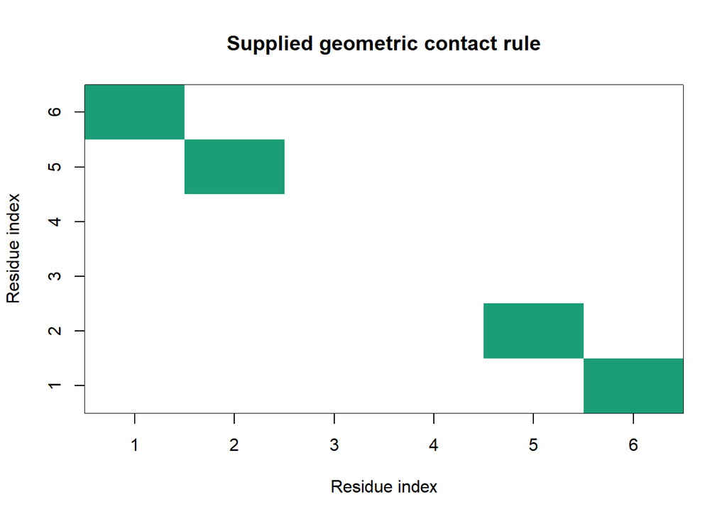

```r
stopifnot(nrow(pairs)==2)
image(1:6,1:6,contact,xlab="Residue index",ylab="Residue index",
 col=c("white","#1b9e77"),main="Supplied geometric contact rule")
```

Contacts describe geometry under the chosen threshold. They are not measured interactions or binding energies.

## 3. Assess threshold dependence

Count contacts at several cutoffs using the same non-neighbour rule.

**Show R code**

```r
cutoffs <- c(4,5,8)
data.frame(cutoff_A=cutoffs,contacts=vapply(cutoffs,function(cut)
 sum((D<cut & abs(row(D)-col(D))>1)[upper.tri(D)]),integer(1)))
```

```
  cutoff_A contacts
1        4        2
2        5        2
3        8        8
```

A contact list changes when its operational definition changes.

## 4. Verify units before defining contacts

The same geometry expressed in angstroms or nanometres requires a correspondingly changed cutoff. A factor-of-ten unit mismatch can drastically alter the adjacency matrix.

**Show R code**

```r
xyz_A <- rbind(c(0,0,0),c(3,0,0),c(0,4,0))
d_A <- as.matrix(dist(xyz_A));d_nm <- as.matrix(dist(xyz_A/10))
stopifnot(max(abs(d_A/10-d_nm))<1e-12,
 identical(d_A<4.5,d_nm<.45))
d_A
```

```
  1 2 3
1 0 3 4
2 3 0 5
3 4 5 0
```

## 5. Interpret a structural representation

A C-alpha contact uses one backbone representative per residue. An all-atom interaction, hydrogen bond or ligand contact has a different definition. Chain identity, missing residues and structural confidence can affect interpretation. A contact threshold is an analysis rule, not a universal biological boundary.

Connect a candidate residue to sequence position carefully, especially when the structural record contains missing segments or a processed chain. A variant near a contact can motivate a hypothesis, but functional evidence and the relevant physiological conformation are needed to support it.

## Interpretation challenge

Would proximity in a predicted structure prove that changing a residue alters animal performance?

**Suggested reasoning**

No. Structural proximity is limited model evidence. Prediction confidence, biochemical function, organism context and an appropriate perturbation or variant study are separate requirements.

## Interpretation and limits

For an actual structure, record accession, model, chain, residue numbering, units, experimental/predicted status and structural uncertainty. A C-alpha cutoff is an abstraction; side chains, ligands, solvent and conformational dynamics affect biological interpretation.

## Exercises

1. What changes when coordinates are converted to nanometres?
2. Why exclude sequential neighbours?
3. Does a contact establish functional necessity?

**Suggested answers**

1. Values divide by ten and the cutoff must also divide by ten.
2. They reflect backbone proximity and can obscure non-local geometry.
3. No; perturbation and functional evidence are needed.

## Continue learning

B08 Proteomics and structure.

Continue with protein abundance. Return to the practical index or the unified map.